# Recognize Handwritten Digits by CNN

Project

Solve a classification problem: A Handwritten Digits Recognition Model based CNN.

Author

Wu Hao

Published

2024/12/26

## Global Settings

We import all the packages here to make us easier to call.

```python
# Numerical Operations
import numpy as np
import math

# Pytorch
import torch
from torch.utils.data import DataLoader, Dataset, random_split
import torch.nn as nn

# For plotting learning curve
from torch.utils.tensorboard import SummaryWriter

# Image Processing
import cv2
# from torchvision import transforms

# Reading/Writing Data
import scipy.io as scio
import os
import csv
import pandas as pd

# Training Process
import sys
import time

# Showing Results
from IPython.display import display
from IPython.display import Image
```

For the reproducibility of the experiment, we fix the random number generator seeds here.

```python
#Fixes random number generator seeds for reproducibility.
def same_seed(seed):
    torch.backends.cudnn.deterministic = True
    torch.backends.cudnn.benchmark = False
    np.random.seed(seed)
    torch.manual_seed(seed)
    if torch.cuda.is_available():
        torch.cuda.manual_seed_all(seed)
```

## Configurations

```python
device = 'cuda' if torch.cuda.is_available() else 'cpu'
config = {
    'seed': 342425,       # seed number, we can pick lucky number. :)
    'test_ratio': float(5000/70000),    # test_size = data_size * test_ratio
    'valid_ratio': 0.2,   # validation_size = train_size * valid_ratio
    'n_epochs': 60,     # Number of epochs.
    'batch_size': 500,
    'learning_rate': 1e-3,
    'early_stop': 400,    # If model has not improved for this many consecutive epochs, stop training.
    'save_path': './recognize_handwritten/model.pt'  # our model will be saved here.
}
```

## Dataset

We can download data from [MNIST](https://yann.lecun.com/exdb/mnist/)

Some basic information about the dataset:

```python
datafile = os.path.join('recognize_handwritten','data','MNIST.mat')
minst_data = scio.loadmat(datafile)

feature = torch.Tensor(minst_data['fea'])
label = torch.Tensor(minst_data['gnd'])

# Stitching features together with labels
minst_data = torch.cat((feature, label), dim = 1 )

print("Shape of data is {}".format(minst_data.shape))
```

```
Shape of data is torch.Size([70000, 785])
```

Since the dataset doesn’t make a distinction between the test_data and the train_data, we’ll have to divide them manually.

```python
def data_split(data_set, ratio, seed):
    split_1_size = int(ratio * len(data_set))
    split_2_size = len(data_set) - split_1_size
    split_2_set, split_1_set = random_split(data_set, [split_2_size, split_1_size], generator=torch.Generator().manual_seed(seed))
    #Proportionally divide split1, the rest is split2
    return np.array(split_2_set), np.array(split_1_set)

train_data, test_data = data_split(minst_data, config['test_ratio'], config['seed'])

print("Shape of train_data is {}".format(train_data.shape))
print("Shape of test_data is {}".format(test_data.shape))
```

```
Shape of train_data is (65000, 785)
Shape of test_data is (5000, 785)
```

## Training Code

### Dataset Processing

We should construct a valid_data first.

```python
train_data, valid_data = data_split(train_data, config['valid_ratio'], config['seed'] )

print("Shape of train_data is {}".format(train_data.shape))
print("Shape of valid_data is {}".format(valid_data.shape))
```

```
Shape of train_data is (52000, 785)
Shape of valid_data is (13000, 785)
```

We processed the dataset into labels with image pixel values.

```python
# extract 784 columns
train_images, valid_images, test_images =train_data[:, :-1], valid_data[:, :-1], test_data[:, :-1]
# extract the last column
train_labels, valid_labels, test_labels =train_data[:, -1], valid_data[:, -1], test_data[:, -1]
print("the shape of features is {}".format(train_images.shape))
```

```
the shape of features is (52000, 784)
```

For images, we should adjust the pixel value of the image to 28×28 shape, and add a dimension.

```python
train_images, valid_images, test_images = train_images.reshape(-1, 1, 28, 28), valid_images.reshape(-1, 1, 28, 28), test_images.reshape(-1, 1, 28, 28)
print("the shape of train_images is {}".format(train_images.shape))
```

```
the shape of train_images is (52000, 1, 28, 28)
```

So, we’ve got three sets of data — train_data, valid_data, and test_data, and we’ve also got their features. Now, it’s time to construct our dataset.

```python
#x: Features.
#y: Targets, if none, do prediction.
class ImgDataset(Dataset):
    def __init__(self, x, y=None, transform=None):
        self.x = torch.FloatTensor(x)
        if y is None:
            self.y = y
        else:
            self.y = torch.LongTensor(y)
        self.transform = transform
    def __getitem__(self, index):
        X = self.x[index]
        if self.transform is not None:
            X = self.transform(X)
        if self.y is not None:
            Y = self.y[index]
            return X, Y
        else:
            return X
    def __len__(self):
        return len(self.x)

# Data Augmentation
# transform = transforms.Compose([
#     transforms.ToPILImage(),               # 将 NumPy 转为 PIL 图像
#     transforms.RandomHorizontalFlip(),     # 随机水平翻转
#     transforms.RandomRotation(15),         # 随机旋转
#     transforms.ToTensor(),                 # 转为张量
#     transforms.Normalize([0.5], [0.5])     # 标准化
# ])

train_dataset, valid_dataset, test_dataset = ImgDataset(train_images, train_labels), \
                                            ImgDataset(valid_images, valid_labels), \
                                            ImgDataset(test_images)

train_loader = DataLoader(train_dataset, batch_size=config['batch_size'], shuffle=True, pin_memory=True)
valid_loader = DataLoader(valid_dataset, batch_size=config['batch_size'], shuffle=True, pin_memory=True)
test_loader = DataLoader(test_dataset, batch_size=config['batch_size'], shuffle=False, pin_memory=True)
```

At this point, we’ve finished building the dataset. With train_loader, we can get bulk data during the training process and pass it to the model. It’s time to construct our model.

### Model

```python
class Classifier(nn.Module):
    def __init__(self, input_dim):
        super(Classifier, self).__init__()
        self.layers = nn.Sequential(
            nn.Conv2d(input_dim, 16, kernel_size=3, stride=1, padding=1),  # [16, 28, 28]
            #nn.BatchNorm2d(16),  Regularization
            nn.ReLU(),
            nn.MaxPool2d(kernel_size=2),  # [16, 14, 14]

            nn.Conv2d(16, 32, kernel_size=3, stride=1, padding=1),  # [32, 14, 14]
            nn.ReLU(),

            nn.Conv2d(32, 64, kernel_size=3, stride=1, padding=1),  # [64, 14, 14]
            nn.ReLU(),
            nn.MaxPool2d(kernel_size=2),  # [64, 7, 7]

        )
        self.fc = nn.Sequential(
            nn.Linear(64 * 7 * 7, 256),
            nn.ReLU(),
            #nn.Dropout(p=0.5), Regularization
            nn.Linear(256, 512),
            nn.ReLU(),
            nn.Linear(512, 10),
        )
#forward propagation
    def forward(self, x):
        out = self.layers(x)
        out = out.view(out.size()[0], -1) #Flattens the tensor to feed it into the fully connected layer.
        return self.fc(out)
```

### Training Loop

```python
def trainer(train_loader, valid_loader, model, config, device):

    criterion = nn.CrossEntropyLoss()  # loss: CrossEntropyLoss
    #optimization algorithm (Adam).
    optimizer = torch.optim.Adam(model.parameters(), lr=config['learning_rate'])

    writer = SummaryWriter() # Writer of tensorboard.

    n_epochs, best_loss, step, early_stop_count = config['n_epochs'], math.inf, 0, 0

    for epoch in range(n_epochs):
        model.train()
        epoch_start_time = time.time()
        loss_record = []
        train_acc = 0.0
        #x: features, y: labels
        for x, y in train_loader:
            optimizer.zero_grad()               # Set gradient to zero.
            x, y = x.to(device), y.to(device)   # Move our data to device.
            train_pred = model(x)
            batch_loss = criterion(train_pred, y)
            batch_loss.backward()               # Compute gradient(back propagation).
            optimizer.step()                    # Update parameters.
            step += 1
            train_acc += np.sum(np.argmax(train_pred.detach().cpu().numpy(), axis=1) == y.cpu().numpy())
            loss_record.append(batch_loss.detach().item()) #detach(): separation gradient

        mean_train_loss = sum(loss_record)/len(loss_record)
        train_acc = train_acc / train_dataset.__len__()
        writer.add_scalar('Loss/train', mean_train_loss, step)
        writer.add_scalar('Accuracy/train', train_acc, step)

        model.eval() # Set our model to evaluation mode.
        loss_record = []
        valid_acc = 0.0
        with torch.no_grad():
            for x, y in valid_loader:
                x, y = x.to(device), y.to(device)
                valid_pred = model(x)
                batch_loss = criterion(valid_pred, y)
                valid_acc += np.sum(np.argmax(valid_pred.detach().cpu().numpy()
, axis=1) == y.cpu().numpy())
                loss_record.append(batch_loss.item())

            mean_valid_loss = sum(loss_record)/len(loss_record)
            valid_acc = valid_acc / valid_dataset.__len__()
            print('[%03d/%03d] %2.2f sec(s) Train Acc: %3.6f Loss: %3.6f | Val Acc: %3.6f loss: %3.6f' % \
              (epoch + 1, n_epochs, time.time() - epoch_start_time, \
               train_acc, mean_train_loss, valid_acc, mean_valid_loss))
            writer.add_scalar('Loss/valid', mean_valid_loss, step)
            writer.add_scalar('Accuracy/valid', valid_acc, step)

        if mean_valid_loss < best_loss:
            best_loss = mean_valid_loss
            torch.save(model.state_dict(), config['save_path']) # Save our best model
            print('Saving model with loss {:.3f}...'.format(best_loss))
            early_stop_count = 0
        else:
            early_stop_count += 1

        if early_stop_count >= config['early_stop']:
            print('\nModel is not improving, so we halt the training session.')
            return
```

### Start Training!!

```python
model = Classifier(input_dim=train_images.shape[1]).to(device) # put our model and data on the same computation device.
trainer(train_loader, valid_loader, model, config, device)
```

```
[001/060] 0.89 sec(s) Train Acc: 0.891885 Loss: 0.409646 | Val Acc: 0.978231 loss: 0.067360
Saving model with loss 0.067...
[002/060] 0.55 sec(s) Train Acc: 0.984231 Loss: 0.048531 | Val Acc: 0.985769 loss: 0.046605
Saving model with loss 0.047...
[003/060] 0.54 sec(s) Train Acc: 0.990885 Loss: 0.027983 | Val Acc: 0.987385 loss: 0.041005
Saving model with loss 0.041...
[004/060] 0.53 sec(s) Train Acc: 0.993615 Loss: 0.019265 | Val Acc: 0.989154 loss: 0.042436
[005/060] 0.65 sec(s) Train Acc: 0.995635 Loss: 0.013021 | Val Acc: 0.989154 loss: 0.041639
[006/060] 0.59 sec(s) Train Acc: 0.996404 Loss: 0.010533 | Val Acc: 0.989615 loss: 0.041016
[007/060] 0.63 sec(s) Train Acc: 0.996827 Loss: 0.009539 | Val Acc: 0.989692 loss: 0.041559
[008/060] 0.55 sec(s) Train Acc: 0.998173 Loss: 0.005425 | Val Acc: 0.989538 loss: 0.050211
[009/060] 0.54 sec(s) Train Acc: 0.996635 Loss: 0.009465 | Val Acc: 0.989231 loss: 0.047003
[010/060] 0.53 sec(s) Train Acc: 0.997885 Loss: 0.006205 | Val Acc: 0.989462 loss: 0.053502
[011/060] 0.60 sec(s) Train Acc: 0.997846 Loss: 0.005888 | Val Acc: 0.989385 loss: 0.055032
[012/060] 0.53 sec(s) Train Acc: 0.997596 Loss: 0.006815 | Val Acc: 0.989385 loss: 0.044530
[013/060] 0.60 sec(s) Train Acc: 0.997673 Loss: 0.006498 | Val Acc: 0.989615 loss: 0.050122
[014/060] 0.56 sec(s) Train Acc: 0.998596 Loss: 0.004570 | Val Acc: 0.990769 loss: 0.044231
[015/060] 0.54 sec(s) Train Acc: 0.998865 Loss: 0.003854 | Val Acc: 0.990154 loss: 0.047966
[016/060] 0.55 sec(s) Train Acc: 0.998231 Loss: 0.005527 | Val Acc: 0.990231 loss: 0.050920
[017/060] 0.58 sec(s) Train Acc: 0.998365 Loss: 0.005089 | Val Acc: 0.990462 loss: 0.047897
[018/060] 0.52 sec(s) Train Acc: 0.998269 Loss: 0.005363 | Val Acc: 0.989154 loss: 0.057243
[019/060] 0.58 sec(s) Train Acc: 0.996712 Loss: 0.010166 | Val Acc: 0.990923 loss: 0.046304
[020/060] 0.54 sec(s) Train Acc: 0.997288 Loss: 0.007299 | Val Acc: 0.990923 loss: 0.052997
[021/060] 0.57 sec(s) Train Acc: 0.998635 Loss: 0.004200 | Val Acc: 0.991000 loss: 0.048511
[022/060] 0.54 sec(s) Train Acc: 0.998923 Loss: 0.003272 | Val Acc: 0.990769 loss: 0.046340
[023/060] 0.59 sec(s) Train Acc: 0.999308 Loss: 0.002122 | Val Acc: 0.988538 loss: 0.064557
[024/060] 0.53 sec(s) Train Acc: 0.998923 Loss: 0.003017 | Val Acc: 0.988308 loss: 0.062949
[025/060] 0.58 sec(s) Train Acc: 0.998788 Loss: 0.003610 | Val Acc: 0.987923 loss: 0.068442
[026/060] 0.53 sec(s) Train Acc: 0.998942 Loss: 0.004020 | Val Acc: 0.990538 loss: 0.055738
[027/060] 0.53 sec(s) Train Acc: 0.998788 Loss: 0.003928 | Val Acc: 0.989615 loss: 0.059165
[028/060] 0.53 sec(s) Train Acc: 0.998519 Loss: 0.005521 | Val Acc: 0.989692 loss: 0.056128
[029/060] 0.58 sec(s) Train Acc: 0.998019 Loss: 0.006326 | Val Acc: 0.990000 loss: 0.050951
[030/060] 0.53 sec(s) Train Acc: 0.998942 Loss: 0.002725 | Val Acc: 0.990154 loss: 0.060366
[031/060] 0.57 sec(s) Train Acc: 0.999654 Loss: 0.000855 | Val Acc: 0.991231 loss: 0.058200
[032/060] 0.53 sec(s) Train Acc: 0.998615 Loss: 0.004642 | Val Acc: 0.989692 loss: 0.061326
[033/060] 0.54 sec(s) Train Acc: 0.998385 Loss: 0.005123 | Val Acc: 0.986231 loss: 0.078621
[034/060] 0.55 sec(s) Train Acc: 0.998019 Loss: 0.007232 | Val Acc: 0.989538 loss: 0.060486
[035/060] 0.61 sec(s) Train Acc: 0.999019 Loss: 0.003902 | Val Acc: 0.989692 loss: 0.066083
[036/060] 0.52 sec(s) Train Acc: 0.998923 Loss: 0.003234 | Val Acc: 0.988923 loss: 0.068510
[037/060] 0.58 sec(s) Train Acc: 0.998827 Loss: 0.003749 | Val Acc: 0.990538 loss: 0.058405
```

[output cut: 8 more lines]

```
[046/060] 0.53 sec(s) Train Acc: 0.999365 Loss: 0.002472 | Val Acc: 0.990615 loss: 0.060955
[047/060] 0.58 sec(s) Train Acc: 0.999846 Loss: 0.000506 | Val Acc: 0.992000 loss: 0.056879
[048/060] 0.53 sec(s) Train Acc: 0.999904 Loss: 0.000182 | Val Acc: 0.991923 loss: 0.060982
[049/060] 0.58 sec(s) Train Acc: 0.999942 Loss: 0.000113 | Val Acc: 0.992000 loss: 0.063224
[050/060] 0.55 sec(s) Train Acc: 1.000000 Loss: 0.000052 | Val Acc: 0.991846 loss: 0.060531
[051/060] 0.56 sec(s) Train Acc: 0.999904 Loss: 0.000483 | Val Acc: 0.990231 loss: 0.071983
[052/060] 0.55 sec(s) Train Acc: 0.999865 Loss: 0.000466 | Val Acc: 0.990000 loss: 0.081223
[053/060] 0.59 sec(s) Train Acc: 0.998558 Loss: 0.005924 | Val Acc: 0.985615 loss: 0.100507
[054/060] 0.52 sec(s) Train Acc: 0.995519 Loss: 0.015970 | Val Acc: 0.987923 loss: 0.067725
[055/060] 0.57 sec(s) Train Acc: 0.998212 Loss: 0.005315 | Val Acc: 0.991615 loss: 0.049598
[056/060] 0.55 sec(s) Train Acc: 0.999481 Loss: 0.001553 | Val Acc: 0.991462 loss: 0.056393
[057/060] 0.55 sec(s) Train Acc: 0.999712 Loss: 0.000877 | Val Acc: 0.992538 loss: 0.053947
[058/060] 0.54 sec(s) Train Acc: 0.999923 Loss: 0.000264 | Val Acc: 0.990769 loss: 0.068854
[059/060] 0.61 sec(s) Train Acc: 0.999615 Loss: 0.001877 | Val Acc: 0.989462 loss: 0.074292
[060/060] 0.55 sec(s) Train Acc: 0.997462 Loss: 0.008940 | Val Acc: 0.987385 loss: 0.078008
```

We can visualize our training progress by Tensorboard.

```bash
tensorboard --logdir=./posts/runs/
```

[figure not shown]

Accuracy

[figure not shown]

Loss

## Testing Code

We use the best model **model.pt** obtained through training to accomplish the classification of handwritten digits.

```python
def predict(test_loader, model, device):
    model.eval() # Set your model to evaluation mode.
    labels = []
    with torch.no_grad():
        for x in test_loader:
            x = x.to(device)
            test_pred = model(x)
            # Find the maximum in test_pred
            test_label = np.argmax(test_pred.detach().cpu().numpy(), axis=1)
            labels.append(test_label)
        labels = np.concatenate(labels, axis=0)
        return labels

model = Classifier(input_dim=train_images.shape[1]).to(device)
model.load_state_dict(torch.load(config['save_path'], weights_only=True))
preds = predict(test_loader, model, device)
```

### Saving Results

```python
def save_pred(preds, file):
    with open(file, 'w') as fp:
        writer = csv.writer(fp)
        writer.writerow(['id', 'tested_results'])
        for i, p in enumerate(preds):
            writer.writerow([i, p])

save_pred(preds, './recognize_handwritten/pred.csv')
display_results = pd.read_csv('./recognize_handwritten/pred.csv')

test_acc = 0.0
for i in range(len(display_results['tested_results'])):
    test_acc += np.sum(display_results['tested_results'][i] == test_labels[i])
test_acc = 100 * test_acc / len(display_results['tested_results'])

print("Accuracy: {}％".format(test_acc))
print("Prediction Results")
print(display_results)
```

```
Accuracy: 98.68％
Prediction Results
        id  tested_results
0        0               8
1        1               5
2        2               4
3        3               4
4        4               0
...    ...             ...
4995  4995               2
4996  4996               9
4997  4997               5
4998  4998               3
4999  4999               8

[5000 rows x 2 columns]
```

## Application

We’re looking to put our models into practice, not just store them in a CSV file. So, we’ll need you to write your numbers on a piece of paper. Then, we’ll process the images on that paper.

```python
# Reversing the black and white thresholds for each pixel
def accessPiexl(img):
    height = img.shape[0]
    width = img.shape[1]
    for i in range(height):
       for j in range(width):
           img[i][j] = 255 - img[i][j]
    return img

# Inverse binarized image
def accessBinary(img, threshold=165):
    img = accessPiexl(img)
    kernel = np.ones((3, 3), np.uint8)
    img = cv2.GaussianBlur(img, (3, 3), 0) #Gaussian filter
    img = cv2.erode(img, kernel, iterations=1) #Border burr removal
    # adaptive filter
    img = cv2.adaptiveThreshold(img, 255, cv2.ADAPTIVE_THRESH_MEAN_C, cv2.THRESH_BINARY, 7, -9)
    img = cv2.dilate(img, kernel, iterations=1)
    return img

# For showing prediction results
def showResults(path, borders, results=None):
    img = cv2.imread(path)
    for i, border in enumerate(borders):
        cv2.rectangle(img, border[0], border[1], (0, 0, 255))
        if results is not None:
            cv2.putText(img, str(results[i]), border[0], cv2.FONT_HERSHEY_COMPLEX, 0.8, (0, 255, 0), 1)
    cv2.waitKey(0)
    cv2.imwrite('recognize_handwritten/out.jpg',img)
    display(Image(filename='recognize_handwritten/out.jpg'))

#Search the edge, and return the top right and bottom left coner of the digits
def findBorderContours(path, maxArea=1800):
    img = cv2.imread(path, cv2.IMREAD_GRAYSCALE)
    img = accessBinary(img)
    contours, hierarchy = cv2.findContours(img, cv2.RETR_EXTERNAL, cv2.CHAIN_APPROX_NONE)
    borders = []
    for contour in contours:
        #creat a boder
        x, y, w, h = cv2.boundingRect(contour)
        if w*h > maxArea:
            #the coordinate of boder
            border = [(x, y), (x+w, y+h)]
            borders.append(border)
    return borders

def transUSPS(path, borders, size=(28, 28)):
    imgData = np.zeros((len(borders), size[0], size[0], 1), dtype='uint8')
    img = cv2.imread(path, cv2.IMREAD_GRAYSCALE)
    img = accessBinary(img)
    for i, border in enumerate(borders):
        borderImg = img[border[0][1]:border[1][1], border[0][0]:border[1][0]]
        #Expand pixels based on maximum edge make the border close to square
        extendPiexl = (max(borderImg.shape) - min(borderImg.shape)) // 2
        #make border
        targetImg = cv2.copyMakeBorder(borderImg, 7, 7, extendPiexl + 7, extendPiexl + 7, cv2.BORDER_CONSTANT)
        targetImg = cv2.resize(targetImg, size)
        # expand dimension
        targetImg = np.expand_dims(targetImg, axis=-1)
        imgData[i] = targetImg
    return imgData
```

## Prediction Results

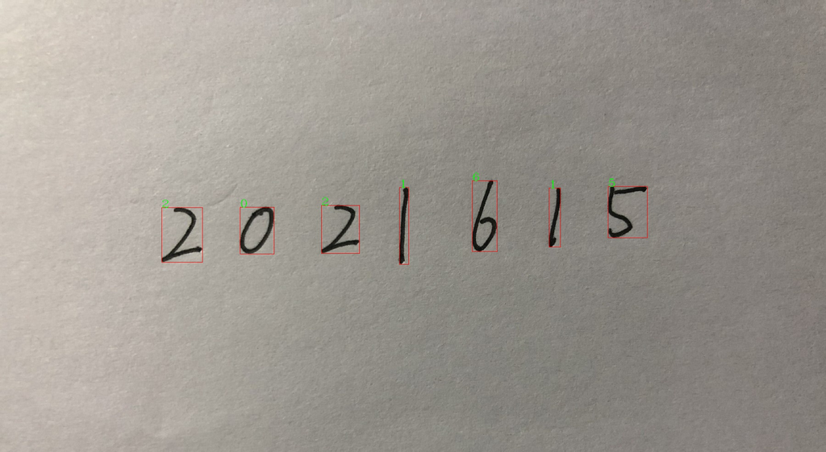

```python
path = 'recognize_handwritten/data/2.jpg'
model = 'recognize_handwritten/model.pt'
borders = findBorderContours(path)

imgData = transUSPS(path, borders)
imgData = np.transpose(imgData,[0,3,1,2])
imgData = ImgDataset(imgData)
test2_loader = DataLoader(imgData, batch_size=1, shuffle=False)

model = Classifier(input_dim=1).to(device)
model.load_state_dict(torch.load(config['save_path'], weights_only=True))
preds = predict(test2_loader, model, device)

showResults(path, borders, preds)
```

Back to top